# Dataset_NYC_311_Calls

## 1. Data Preparation

### 1.1. Import the dataset

Code:

```python
# Import the pandas  library for data manipulation
import pandas as pd

# Load the dataset from a CSV file with memory optimization disabled
df = pd.read_csv('Customer Service_Requests_from_2010_to_Present.csv', low_memory=False)

print("Dataset imported successfully.")

# Display the first five rows of the dataset to preview its structure
df.head()
```

```
Dataset imported successfully.
```

|  | Unique Key | Created Date | Closed Date | Agency | Agency Name | Complaint Type | Descriptor | Location Type | Incident Zip | Incident Address | ... | Bridge Highway Name | Bridge Highway Direction | Road Ramp | Bridge Highway Segment | Garage Lot Name | Ferry Direction | Ferry Terminal Name | Latitude | Longitude | Location |
| --- | --- | --- | --- | --- | --- | --- | --- | --- | --- | --- | --- | --- | --- | --- | --- | --- | --- | --- | --- | --- | --- |
| 0 | 32310363 | 12/31/2015 11:59:45 PM | 01-01-16 0:55 | NYPD | New York City Police Department | Noise - Street/Sidewalk | Loud Music/Party | Street/Sidewalk | 10034.0 | 71 VERMILYEA AVENUE | ... | NaN | NaN | NaN | NaN | NaN | NaN | NaN | 40.865682 | -73.923501 | (40.86568153633767, -73.92350095571744) |
| 1 | 32309934 | 12/31/2015 11:59:44 PM | 01-01-16 1:26 | NYPD | New York City Police Department | Blocked Driveway | No Access | Street/Sidewalk | 11105.0 | 27-07 23 AVENUE | ... | NaN | NaN | NaN | NaN | NaN | NaN | NaN | 40.775945 | -73.915094 | (40.775945312321085, -73.91509393898605) |
| 2 | 32309159 | 12/31/2015 11:59:29 PM | 01-01-16 4:51 | NYPD | New York City Police Department | Blocked Driveway | No Access | Street/Sidewalk | 10458.0 | 2897 VALENTINE AVENUE | ... | NaN | NaN | NaN | NaN | NaN | NaN | NaN | 40.870325 | -73.888525 | (40.870324522111424, -73.88852464418646) |
| 3 | 32305098 | 12/31/2015 11:57:46 PM | 01-01-16 7:43 | NYPD | New York City Police Department | Illegal Parking | Commercial Overnight Parking | Street/Sidewalk | 10461.0 | 2940 BAISLEY AVENUE | ... | NaN | NaN | NaN | NaN | NaN | NaN | NaN | 40.835994 | -73.828379 | (40.83599404683083, -73.82837939584206) |
| 4 | 32306529 | 12/31/2015 11:56:58 PM | 01-01-16 3:24 | NYPD | New York City Police Department | Illegal Parking | Blocked Sidewalk | Street/Sidewalk | 11373.0 | 87-14 57 ROAD | ... | NaN | NaN | NaN | NaN | NaN | NaN | NaN | 40.733060 | -73.874170 | (40.733059618956815, -73.87416975810375) |

5 rows × 53 columns

### 1.2. Provide your insight on the information and details that the provided dataset carries.

Code:

```python
# Display column names, non-null counts, and data types
print("Dataset Info:")
print(df.info())

# Show descriptive statistics for all columns, including categorical
print("\nDescriptive Statistics:")
df.describe(include='all')
```

[output not shown]

[output cut: 50 more lines]

[output not shown]

### 1.3. Convert the columns "Created Date" and "Closed Date" to datetime datatype and create a new column "Request_Closing_Time" as the time elapsed between request creation and request closing.

Code:

```python
# Converting the columns "Created Date" and "Closed Date" to datetime datatype
# - errors='coerce' turns any unparsable value into NaT (missing datetime).
df['Created Date'] = pd.to_datetime(df['Created Date'], errors='coerce')

df['Closed Date'] = pd.to_datetime(df['Closed Date'],  errors='coerce')

# Creating a new column "Request_Closing_Time"
df['Request_Closing_Time'] = df['Closed Date'] - df['Created Date']

print("Request_Closing_Time column created.")

df[['Created Date', 'Closed Date', 'Request_Closing_Time']].head()
```

```
Request_Closing_Time column created.
```

|  | Created Date | Closed Date | Request_Closing_Time |
| --- | --- | --- | --- |
| 0 | 2015-12-31 23:59:45 | 2016-01-01 00:55:00 | 0 days 00:55:15 |
| 1 | 2015-12-31 23:59:44 | 2016-01-01 01:26:00 | 0 days 01:26:16 |
| 2 | 2015-12-31 23:59:29 | 2016-01-01 04:51:00 | 0 days 04:51:31 |
| 3 | 2015-12-31 23:57:46 | 2016-01-01 07:43:00 | 0 days 07:45:14 |
| 4 | 2015-12-31 23:56:58 | 2016-01-01 03:24:00 | 0 days 03:27:02 |

### 1.4. Drop the irrelevant columns

Code:

```python
# Define a list of columns to drop.
columns_to_drop = [
    'Agency Name', 'Incident Address', 'Street Name', 'Cross Street 1', 'Cross Street 2',
    'Intersection Street 1', 'Intersection Street 2', 'Address Type', 'Park Facility Name',
    'Park Borough', 'School Name', 'School Number', 'School Region', 'School Code',
    'School Phone Number', 'School Address', 'School City', 'School State', 'School Zip',
    'School Not Found', 'School or Citywide Complaint', 'Vehicle Type', 'Taxi Company Borough',
    'Taxi Pick Up Location', 'Bridge Highway Name', 'Bridge Highway Direction', 'Road Ramp',
    'Bridge Highway Segment', 'Garage Lot Name', 'Ferry Direction', 'Ferry Terminal Name',
    'Landmark', 'X Coordinate (State Plane)', 'Y Coordinate (State Plane)', 'Due Date',
    'Resolution Action Updated Date', 'Community Board', 'Facility Type', 'Location'
]

# Drop the irrelevant columns
df.drop(columns=columns_to_drop, axis=1, inplace=True, errors='ignore')
print("Irrelevant columns dropped.")
df.head()
```

```
Irrelevant columns dropped.
```

|  | Unique Key | Created Date | Closed Date | Agency | Complaint Type | Descriptor | Location Type | Incident Zip | City | Status | Resolution Description | Borough | Latitude | Longitude | Request_Closing_Time |
| --- | --- | --- | --- | --- | --- | --- | --- | --- | --- | --- | --- | --- | --- | --- | --- |
| 0 | 32310363 | 2015-12-31 23:59:45 | 2016-01-01 00:55:00 | NYPD | Noise - Street/Sidewalk | Loud Music/Party | Street/Sidewalk | 10034.0 | NEW YORK | Closed | The Police Department responded and upon arriv... | MANHATTAN | 40.865682 | -73.923501 | 0 days 00:55:15 |
| 1 | 32309934 | 2015-12-31 23:59:44 | 2016-01-01 01:26:00 | NYPD | Blocked Driveway | No Access | Street/Sidewalk | 11105.0 | ASTORIA | Closed | The Police Department responded to the complai... | QUEENS | 40.775945 | -73.915094 | 0 days 01:26:16 |
| 2 | 32309159 | 2015-12-31 23:59:29 | 2016-01-01 04:51:00 | NYPD | Blocked Driveway | No Access | Street/Sidewalk | 10458.0 | BRONX | Closed | The Police Department responded and upon arriv... | BRONX | 40.870325 | -73.888525 | 0 days 04:51:31 |
| 3 | 32305098 | 2015-12-31 23:57:46 | 2016-01-01 07:43:00 | NYPD | Illegal Parking | Commercial Overnight Parking | Street/Sidewalk | 10461.0 | BRONX | Closed | The Police Department responded to the complai... | BRONX | 40.835994 | -73.828379 | 0 days 07:45:14 |
| 4 | 32306529 | 2015-12-31 23:56:58 | 2016-01-01 03:24:00 | NYPD | Illegal Parking | Blocked Sidewalk | Street/Sidewalk | 11373.0 | ELMHURST | Closed | The Police Department responded and upon arriv... | QUEENS | 40.733060 | -73.874170 | 0 days 03:27:02 |

### 1.5. Write a python program to remove the NaN missing values from updated dataframe.

Code:

```python
# Remove all rows that contain any missing (NaN) values in any column.
df_cleaned = df.dropna()

# Print how many rows were removed during cleaning.
print("Missing values handled. Number of rows before cleaning: {}, after cleaning: {}"
      .format(len(df), len(df_cleaned)))
```

```
Missing values handled. Number of rows before cleaning: 300698, after cleaning: 291107
```

### 1.6. Write a python program to see the unique values from all the columns in the dataframe.

Code:

```python
# Print the number of unique values in each column of the cleaned dataset.
print("Unique values in each column:")
for col in df_cleaned.columns:
    print(f"{col}: {df_cleaned[col].nunique()} unique values")
```

```
Unique values in each column:
Unique Key: 291107 unique values
Created Date: 251970 unique values
Closed Date: 231991 unique values
Agency: 1 unique values
Complaint Type: 15 unique values
Descriptor: 41 unique values
Location Type: 14 unique values
Incident Zip: 200 unique values
City: 53 unique values
Status: 1 unique values
Resolution Description: 12 unique values
Borough: 5 unique values
Latitude: 123013 unique values
Longitude: 123112 unique values
Request_Closing_Time: 47134 unique values
```

## 2. Data Analysis

### 2.1. Write a Python program to show summary statistics of sum, mean, standard deviation, skewness, and kurtosis of the data frame. of the data frame.

Code:

```python
import pandas as pd

# Compute basic summary statistics for all numeric columns in the cleaned dataset.
# - sum: total of all values
# - mean: average value
# - std: standard deviation (spread)
# - skew: measure of asymmetry in the distribution
# - kurtosis: measure of tail heaviness (outliers)
sum_stats      = df_cleaned.sum(numeric_only=True)
mean_stats     = df_cleaned.mean(numeric_only=True)
std_stats      = df_cleaned.std(numeric_only=True)
skew_stats     = df_cleaned.skew(numeric_only=True)
kurtosis_stats = df_cleaned.kurtosis(numeric_only=True)

# Combine all computed statistics into a single DataFrame for a clean summary table
stats_table = pd.DataFrame({
    'sum'      : sum_stats,
    'mean'     : mean_stats,
    'std'      : std_stats,
    'skew'     : skew_stats,
    'kurtosis' : kurtosis_stats
})

# Display the summary statistics table
display(stats_table)
```

|  | sum | mean | std | skew | kurtosis |
| --- | --- | --- | --- | --- | --- |
| Unique Key | 9.112108e+12 | 3.130158e+07 | 575377.738707 | 0.016898 | -1.176593 |
| Incident Zip | 3.160833e+09 | 1.085798e+04 | 580.280774 | -2.553956 | 37.827777 |
| Latitude | 1.185553e+07 | 4.072568e+01 | 0.082411 | 0.123114 | -0.734818 |
| Longitude | -2.152010e+07 | -7.392504e+01 | 0.078654 | -0.312739 | 1.455600 |

### 2.2. Write a Python program to calculate and show correlation of all variables.

Code:

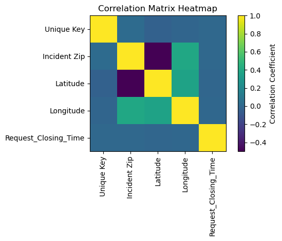

```python
# Import visualization libraries
import matplotlib.pyplot as plt
import seaborn as sns

# Select only the numeric columns from the dataset.
# This is necessary because correlation can only be calculated on numerical data.
numeric_df = df.select_dtypes(include=['number'])

# Compute the correlation matrix for all numeric variables
corr_matrix = numeric_df.corr()

# Display a heatmap of the correlation matrix using matplotlib
plt.figure()
plt.imshow(corr_matrix, aspect='equal')  # Show as square cells
plt.title('Correlation Matrix Heatmap')
plt.xticks(range(len(corr_matrix.columns)), corr_matrix.columns, rotation=90)
plt.yticks(range(len(corr_matrix.index)), corr_matrix.index)
plt.colorbar(label='Correlation Coefficient')   # Add color legend
plt.tight_layout()
plt.show()
```

## 3. Data Exploration

### 3.1. Provide four major insights through visualization that you come up after data mining.

#### 3.1.1. Top 10 Complaint Types

Code:

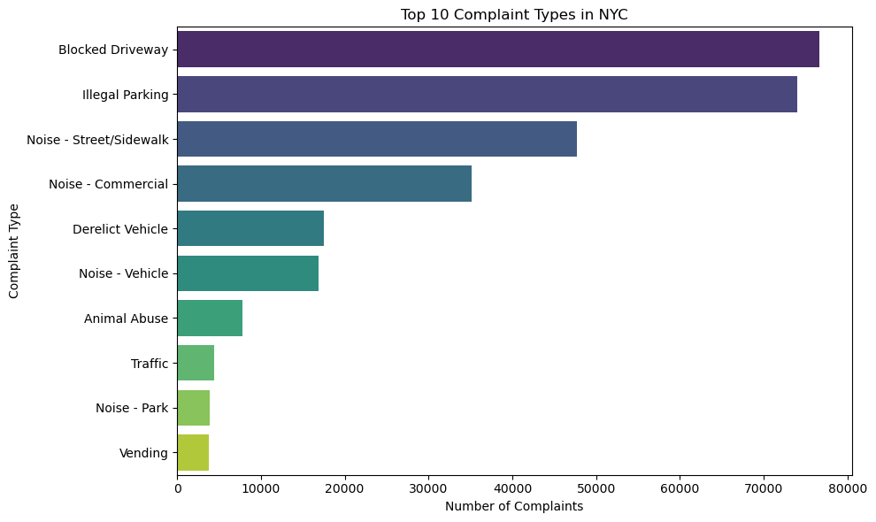

```python
import seaborn as sns
import matplotlib.pyplot as plt

# Get the top 10 most frequent complaint types dataset
top_complaints = df_cleaned['Complaint Type'].value_counts().head(10)

# Convert the Series to a DataFrame for easier plotting
complaints = top_complaints.reset_index()
complaints.columns = ['Complaint Type', 'Count']

# Set up the figure size for better readability
plt.figure(figsize=(10, 6))

# Create a horizontal bar plot using seaborn
# - x: number of complaints
# - y: complaint types
# - hue: adds color separation by complaint type
sns.barplot(
    data=complaints,
    x='Count',
    y='Complaint Type',
    hue='Complaint Type',
    palette='viridis',
    legend=False
)
plt.xlabel("Number of Complaints")
plt.title("Top 10 Complaint Types in NYC")

# Ensure layout fits well within the figure
plt.tight_layout()

# Display the bar chart
plt.show()
```

#### 3.1.2 Distribution of Complaints by Borough

Code:

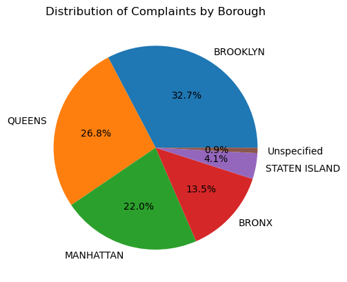

```python
# Create a new figure for the pie chart
plt.figure()

# Count the number of complaints in each borough
borough_counts = df['Borough'].value_counts()

# Plot a pie chart of complaint distribution by borough
# - labels: borough names
# - autopct: show percentage values with one decimal place
plt.pie(borough_counts, labels=borough_counts.index, autopct='%1.1f%%')


plt.title('Distribution of Complaints by Borough')

plt.show()
```

#### 3.1.3. Frequency of Complaints Over Time

Code:

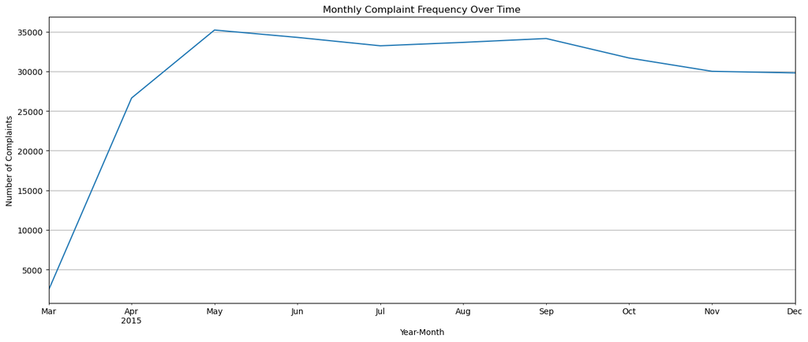

```python
# Create a copy of the DataFrame to avoid SettingWithCopyWarning
df_cleaned = df.dropna().copy()

# Ensure the "Created Date" column is in datetime format
df_cleaned['Created Date'] = pd.to_datetime(df_cleaned['Created Date'])

# Create a new column combining year and month (for monthly grouping)
df_cleaned['YearMonth'] = df_cleaned['Created Date'].dt.to_period('M')

# Group the dataset by YearMonth and count the number of complaints per month
complaints_over_time = df_cleaned.groupby('YearMonth').size()

# Set up the plot size
plt.figure(figsize=(14, 6))

# Plot the time series of monthly complaints
complaints_over_time.plot(figsize=(14, 6))

# Add labels and title for clarity
plt.title("Monthly Complaint Frequency Over Time")
plt.ylabel("Number of Complaints")
plt.xlabel("Year-Month")

# Add gridlines for readability
plt.grid(True)

# Adjust layout to prevent label clipping
plt.tight_layout()

# Display the plot
plt.show()
```

#### 3.1.4. Weekly Cycle of Service Requests

Code:

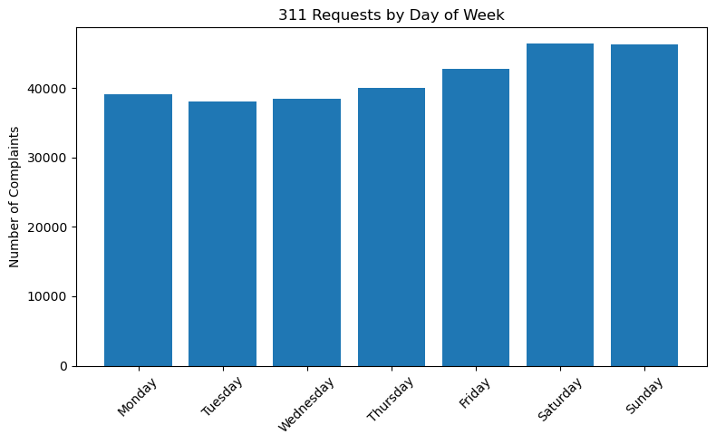

```python
# Extract the day of the week from the "Created Date" column
# This will be used to analyze complaint frequency by weekday
df_cleaned['DayOfWeek'] = df_cleaned['Created Date'].dt.day_name()

# Define the desired order for days of the week
order = ['Monday', 'Tuesday', 'Wednesday', 'Thursday', 'Friday', 'Saturday', 'Sunday']

# Count the number of complaints for each day and reorder them to match the week structure
counts = df_cleaned['DayOfWeek'].value_counts().reindex(order)

import matplotlib.pyplot as plt

# Set the figure size for readability
plt.figure(figsize=(8, 5))

# Plot a bar chart showing the number of complaints per day of the week
plt.bar(counts.index, counts.values)

# Rotate x-axis labels for better readability
plt.xticks(rotation=45)

# Label the y-axis and add a title to the chart
plt.ylabel('Number of Complaints')
plt.title('311 Requests by Day of Week')

# Adjust layout to prevent clipping of labels
plt.tight_layout()

# Display the bar chart
plt.show()
```

Code:

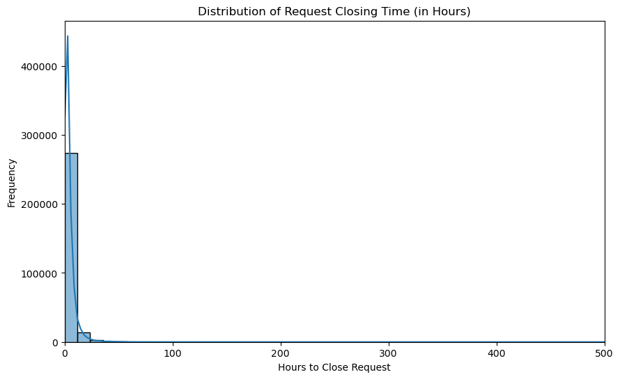

```python
# Ensure the "Request_Closing_Time" column is treated as a timedelta object
# errors='coerce' ensures that invalid formats are converted to NaT (missing)
df_cleaned['Request_Closing_Time'] = pd.to_timedelta(df_cleaned['Request_Closing_Time'], errors='coerce')

# Convert the timedelta to total hours (as a float) for easier analysis and plotting
df_cleaned['Request_Closing_Time_Hours'] = df_cleaned['Request_Closing_Time'].dt.total_seconds() / 3600

# Set figure size for the histogram
plt.figure(figsize=(10, 6))

# Plot the distribution of request closing times using seaborn
# - bins=50: number of bars
# - kde=True: adds a smooth curve representing the distribution
sns.histplot(df_cleaned['Request_Closing_Time_Hours'], bins=50, kde=True)

# Limit the x-axis to 0–500 hours to focus on the majority of cases
plt.xlim(0, 500)

# Add title and axis labels for clarity
plt.title("Distribution of Request Closing Time (in Hours)")
plt.xlabel("Hours to Close Request")
plt.ylabel("Frequency")

# Show the histogram
plt.show()
```

## 4. Statistical Testing

### 4.1. Test 1: Whether the average response time across complaint types is similar or not.

#### ● Perform the statistical test and provide the p-value.

Code:

```python
from scipy.stats import f_oneway

# Convert the "Request_Closing_Time" timedelta column into hours (float) for analysis
df_cleaned.loc[:, 'Request_Closing_Hours'] = (
    df_cleaned['Request_Closing_Time'].dt.total_seconds() / 3600
)

# Identify the top 3 most frequent complaint types for comparison
top3 = df_cleaned['Complaint Type'].value_counts().nlargest(3).index.tolist()

# Extract the closing time data (in hours) for each of the top 3 complaint types
# Each group's data will be used as a sample in the ANOVA test
groups = [
    df_cleaned.loc[df_cleaned['Complaint Type'] == c, 'Request_Closing_Hours']
    for c in top3
]

# Perform one-way ANOVA to test if the average response times differ across complaint types
F_stat, p_val = f_oneway(*groups)

# Output the F-statistic and p-value to interpret the test result
print(f"ANOVA result: F = {F_stat:.3f}, p = {p_val:.3f}")
```

```
ANOVA result: F = 804.923, p = 0.000
```

### 4.2. Test 2: Whether the type of complaint or service requested and location are related.

#### ● Perform the statistical test and provide the p-value.

Code:

```python
from scipy.stats import chi2_contingency
import pandas as pd

# Create a contingency table showing the frequency of each complaint type across boroughs
# Rows: Complaint Types | Columns: Boroughs | Values: Count of occurrences
contingency = pd.crosstab(df_cleaned['Complaint Type'], df_cleaned['Borough'])

# Perform the chi-square test of independence to determine if complaint type is related to borough
chi2, p_val, dof, expected = chi2_contingency(contingency)

# Print the chi-square statistic, p-value, and degrees of freedom
print(f"Chi-square result: χ² = {chi2:.2f}, p = {p_val:.3f}, dof = {dof}")
```

```
Chi-square result: χ² = 73264.62, p = 0.000, dof = 56
```